# Lab 13

Author

Caleb Lawyer

## Prompt

Walk through a tidyverse worfklow in which we do a co-occurrence network analysis with the data.

### Step 1: Load data

```r
library(tidyverse)
library(igraph)
library(ggraph)
```

```r
mags <- read_csv("NEON_soilMAGs_soilChem.csv")

# Select only the columns we need for co-occurrence analysis
# Here: sample ID + taxonomy levels
taxa_data <- mags %>%
  select(genomicsSampleID, phylum, class, order, family, genus, site_ID)

# Quick check of the structure
glimpse(taxa_data)
```

```
Rows: 5,573
Columns: 7
$ genomicsSampleID <chr> "BONA_001-O-20230710", "BONA_001-O-20230710", "BONA_0…
$ phylum           <chr> "Acidobacteriota", "Actinomycetota", "Actinomycetota"…
$ class            <chr> "Terriglobia", "Thermoleophilia", "Thermoleophilia", …
$ order            <chr> "Terriglobales", "Solirubrobacterales", "Solirubrobac…
$ family           <chr> "SbA1", "Solirubrobacteraceae", "Solirubrobacteraceae…
$ genus            <chr> "Sulfotelmatobacter", "Palsa-744", "Palsa-744", "Sulf…
$ site_ID          <chr> "BONA", "BONA", "BONA", "BONA", "BONA", "BONA", "BONA…
```

### Step 2: Build a presence/absence matrix

We want to know which taxa are present in each sample. This creates a sample × genus matrix with 1/0 values.

```r
# Filter to genus level (you could swap for phylum/class/etc.)
# Remove NAs to avoid empty taxa
genus_matrix <- taxa_data %>%
  filter(!is.na(genus)) %>%
  # Keep unique sample-genus combinations
  distinct(genomicsSampleID, genus) %>%
  # Add a presence indicator
  mutate(presence = 1) %>%
  # Pivot wider: samples as rows, genera as columns
  pivot_wider(names_from = genus, values_from = presence, values_fill = 0)

# Now each row = one sample, each column = one genus, values = 1/0
```

### Step 3: Compute co‑occurrence counts

We calculate how often pairs of genera co‑occur across samples.

```r
# Convert back to long format: one row per sample-genus presence
genus_long <- genus_matrix %>%
  pivot_longer(-genomicsSampleID, names_to = "genus", values_to = "presence") %>%
  filter(presence == 1)

# Self-join on sample ID to find all genus pairs within each sample
co_occurrence <- genus_long %>%
  inner_join(genus_long, by = "genomicsSampleID") %>%
  # Avoid self-pairs (genus with itself) and duplicate ordering
  filter(genus.x < genus.y) %>%
  # Count how many samples each pair co-occurs in
  count(genus.x, genus.y, name = "co_count") %>%
  arrange(desc(co_count))

# co_occurrence is now an edge list: genus.x, genus.y, co_count
```

### Step 4: Build and visualize the network

We use igraph + ggraph to turn the edge list into a network.

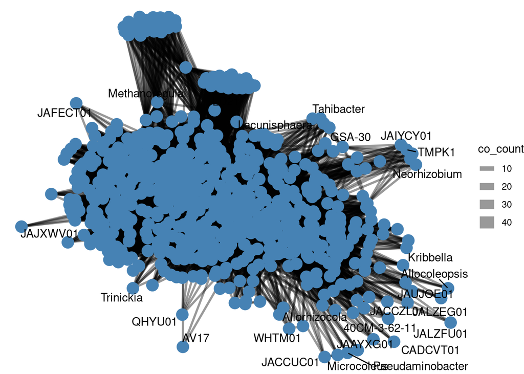

```r
# Keep only top 50 genera by abundance
top_genera <- taxa_data %>%
  count(genus, sort = TRUE) %>%
  slice_head(n = 50) %>%
  pull(genus)

# Filter edge list to include only top genera
co_occurrence_filtered <- co_occurrence %>%
  filter(genus.x %in% top_genera & genus.y %in% top_genera)

# Create igraph object from edge list
g <- graph_from_data_frame(co_occurrence, directed = FALSE)

# Plot the network
ggraph(g, layout = "fr") +   # "fr" = force-directed layout
  geom_edge_link(aes(width = co_count), alpha = 0.4) +  # edges sized by co-occurrence strength
  geom_node_point(color = "steelblue", size = 5) +      # nodes = genera
  geom_node_text(aes(label = name), repel = TRUE) +     # labels for genera
  theme_void()
```

### Step 5: Add ecological meaning

You can refine the network to highlight meaningful relationships.

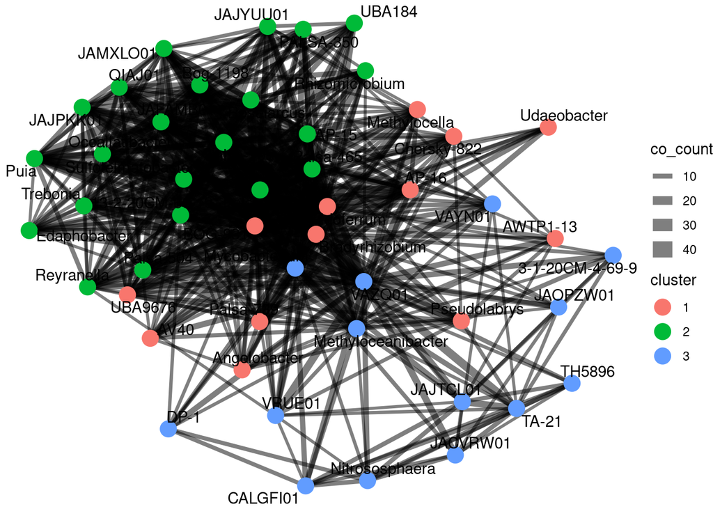

```r
# Filter edges to keep only strong co-occurrences
co_occurrence_clean <- co_occurrence_filtered %>% filter(co_count >= 5)

# Rebuild network with filtered edges
g_filtered <- graph_from_data_frame(co_occurrence_clean, directed = FALSE)

# Plot with phylum coloring (join taxonomy back to nodes first)
# Example: assume you have a node metadata table with genus → phylum
node_taxonomy <- taxa_data %>%
  distinct(genus, phylum)

# Apply Louvain algorithm
clusters <- cluster_louvain(g_filtered)
V(g_filtered)$cluster <- as.factor(clusters$membership)

# Add taxonomy info to igraph nodes
V(g_filtered)$phylum <- node_taxonomy$phylum[match(V(g_filtered)$name, node_taxonomy$genus)]

# Visualize with phylum colors
ggraph(g_filtered, layout = "kk") +
  geom_edge_link(aes(width = co_count), alpha = 0.5) +
  geom_node_point(aes(color = cluster), size = 5) +
  geom_node_text(aes(label = name), repel = TRUE) +
  theme_void()
```

## Explanation

(I asked copilot many times for strategies on how to reduce the clutter of the graph, and even tried regenerating the code completely. This is the most legible graph I have been able to achieve.)

A co-occurence network analysis describes the frequency with which certain taxa share specific MAG samples. In the graph, each node represents a taxonomic level, the genus. Key genera are labeled. The “arms” of the graph are called edges, and they represent the co-occurence relationship between genera. The wider the edge, the more times that pair of genera was shared in a MAG sample.

The nodes are colored by the Louvain community detection algorithm. This method measures “modularity”, a score that represents how strongly different communities are correlated compared to random chance. Nodes are colored to represent their interconnectedness, further grouping them into “supernodes”.